# Prognozowanie szeregów czasowych

Aleksandra Węgrzyn

2026-03-07

## 1. Wprowadzenie

Celem niniejszego projektu jest przeprowadzenie analizy wybranego szeregu czasowego oraz porównanie skuteczności różnych metod prognozowania. W ramach pracy zbadane zostaną właściwości szeregu, a następnie zbudowane i ocenione zostaną modele predykcyjne m.in. Holta-Wintersa, ETS oraz ARIMA. Uzyskane wyniki umożliwią wskazanie metody, zapewniającej najwyższą trafność prognoz dla analizowanego zjawiska.

### 1.1. Opis zbioru danych

Zestaw danych wykorzystany w badaniu stanowi podzbior wylosowany za pomocą numeru indeksu 417977 ze zbioru `aus_retail`. Zawiera on 441 obserwacji. Dane te dotyczą miesięcznych wartości sprzedaży w sektorze gastronomii w stanie Queensland od kwietnia 1982 do grudnia 2018.

Zmienne:

- **`State`** - stan lub terytorium Australii, dla którego raportowane są dane
- **`Industry`** - branża handlu detalicznego, którego dotyczą obroty
- **`SeriesID`** - identyfikator serii
- **`Month`** - miesiąc i rok
- **`Turnover`** - wartość obrotów detalicznych w danym miesiącu [mln dolarów australijskich]

| State | Industry | Series ID | Month | Turnover |
| --- | --- | --- | --- | --- |
| Queensland | Cafes, restaurants and takeaway food services | A3349411J | 1982 kwi | 45.4 |
| Queensland | Cafes, restaurants and takeaway food services | A3349411J | 1982 maj | 46.8 |
| Queensland | Cafes, restaurants and takeaway food services | A3349411J | 1982 cze | 44.8 |
| Queensland | Cafes, restaurants and takeaway food services | A3349411J | 1982 lip | 47.8 |
| Queensland | Cafes, restaurants and takeaway food services | A3349411J | 1982 sie | 48.2 |
| Queensland | Cafes, restaurants and takeaway food services | A3349411J | 1982 wrz | 49.8 |

## 2. Wstępna analiza danych

### 2.1. Charakterystyka szeregu czasowego

Analizę rozpoczęto od wizualizacji rozważanego szeregu czasowego.

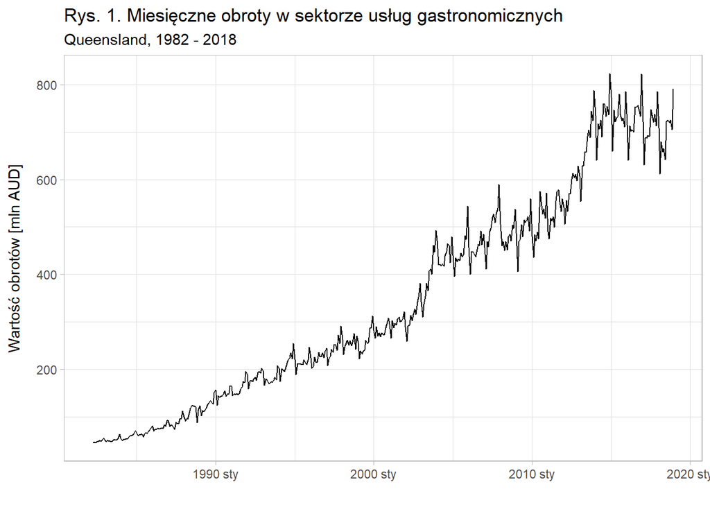

Na powyższym wykresie można dostrzec wyraźny, długookresowy trend wzrostowy. W kwietniu 1982 roku wartość obrotów wynosiła 45.4 mln dolarów australijskich, podczas gdy w grudniu 2018 roku osiągnęła poziom 791 mln AUD. Wizualizacja wskazuje również na występowanie sezonowości, o czym świadczą regularne wahania obserwowane w ciągu roku. Wraz z upływem czasu amplituda tych wahań ulega zwiększeniu, co jednoznacznie sugeruje sezonowość o charakterze multiplikatywnym.

Kolejno dokonano analizy sezonowości z wykorzystaniem wykresu sezonowego. Pozwoliło to na porównanie przebiegu szeregu w poszczególnych latach oraz ocenę powtarzalności zaobserwowanych wcześniej wzorców.

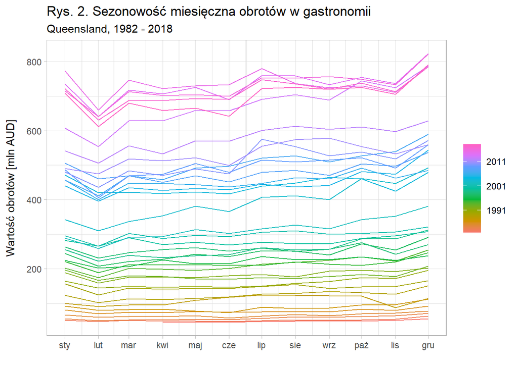

Analiza wykresu sezonowego potwierdza, że najwyższe obroty dla sektora gastronomii są odnotowywane w grudniu. Zjawisko to jest ściśle związane ze wzmożonym ruchem w okresie świątecznym, który sprzyja częstszym spotkaniom rodzinnym bądź towarzyskim w kawiarniach oraz innych lokalach gastronomicznych. Ponadto, sprzedaż w tym sektorze wzrasta ze względu na przypadające w tym okresie w Australii wakacje letnie, które w sposób naturalny zwiększają popyt na usługi gastronomiczne. Natomiast w kolejnych miesiącach, w szczególności w lutym, obserwuje się spadek obrotów, będący konsekwencją wcześniejszych, zwiększonych wydatków konsumentów.

Jako uzupełnienie analizy zastosowano wykres podserii, pozwalający na porównanie kształtowania się wartości obrotów pomiędzy poszczególnymi miesiącami.

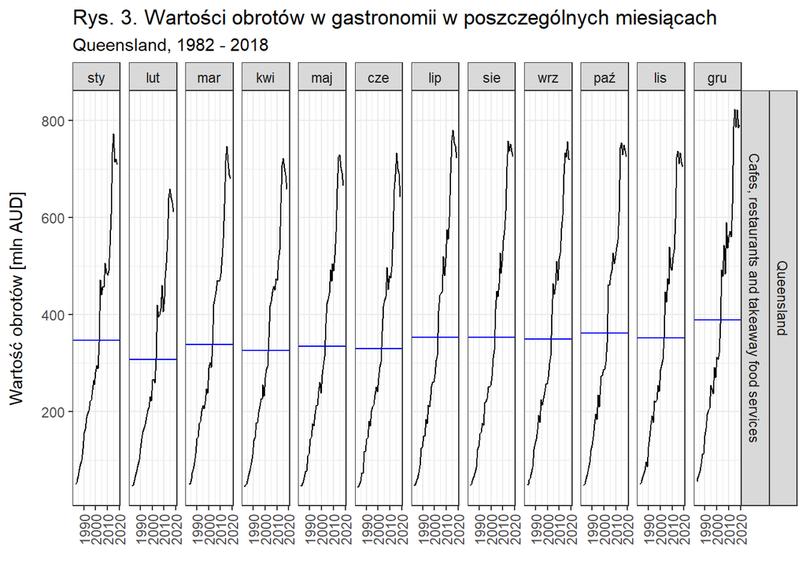

W każdym miesiącu można zaobserwować wyraźny trend wzrostowy. Widoczne w poszczególnych panelach poziome linie, które reprezentują średnią wartość obrotów dla danego miesiąca z całego badanego okresu, w większości przypadków utrzymują się na zbliżonym poziomie. Wyjątkami są grudzień i luty, dla których wartości te są odpowiednio znacznie wyższe oraz zauważalnie niższe w porównaniu z pozostałymi miesiącami.

Nastepnie przeanalizowano zależności pomiędzy poszczególnymi obserwacjami przy pomocy wykresu opóźnień.

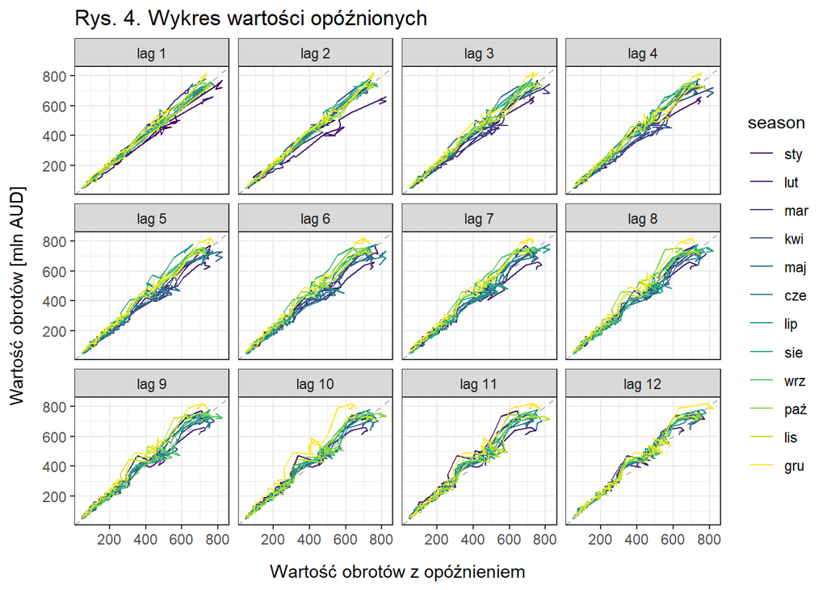

Wykres wartości opóźnionych (Rys. 4) potwierdza występowanie sezonowości w analizowanym szeregu. Najbardziej zwarte, liniowe ułożenie punktów widoczne jest dla opóźnienia równego 12 miesięcy, co wskazuje na silną autokorelację sezonową. Oznacza to, że wartości obrotów w danym miesiącu są silnie powiązane z wartościami obserwowanymi w tym samym miesiącu roku poprzedniego.

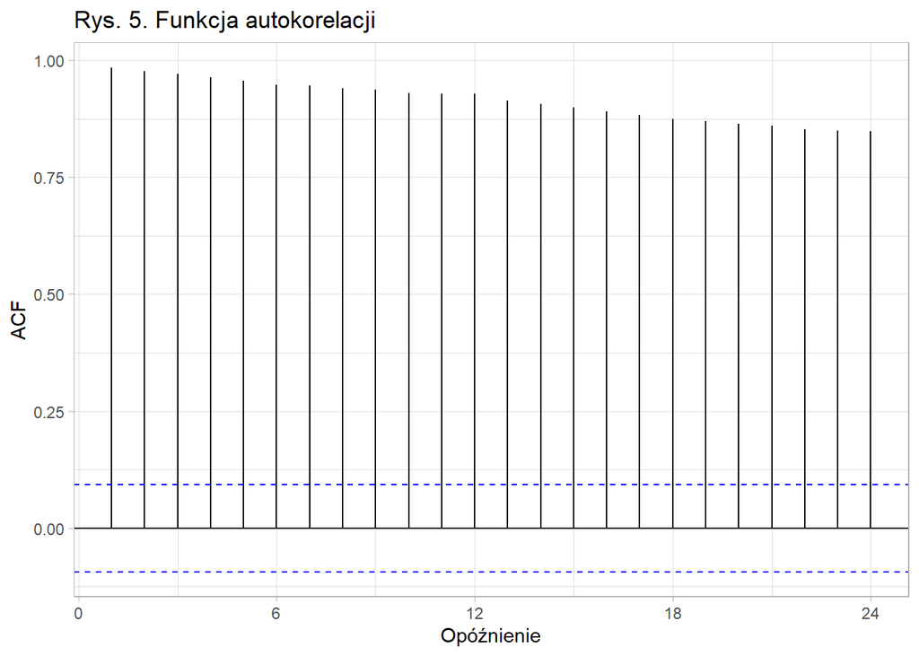

Wykres funkcji autokorelacji wykazuje wysokie wartości utrzymujace się dla kolejnych opóźnień, co dowodzi obecności silnego trendu i wskazuje na niestacjonalność analizowanego szeregu czasowego.

### 2.2. Dekompozycja STL

Poniższy wykres przedstawia dekompozycję analizowanego szeregu czasowego z wykorzystaniem metody STL, przy zastosowaniu domyślnych parametrów wygładzania. Wizualizacja obejmuje oryginalny szereg czasowy (**`Turnover`**), oraz wynik jego dekompozycji na trzy komponenty: składową trendu (**`trend`**), składową sezonową (**`season_year`**) i składnik losowy (**`remainder`**), będący pozostałością po wyeliminowaniu wpływu trendu i sezonowości z danych.

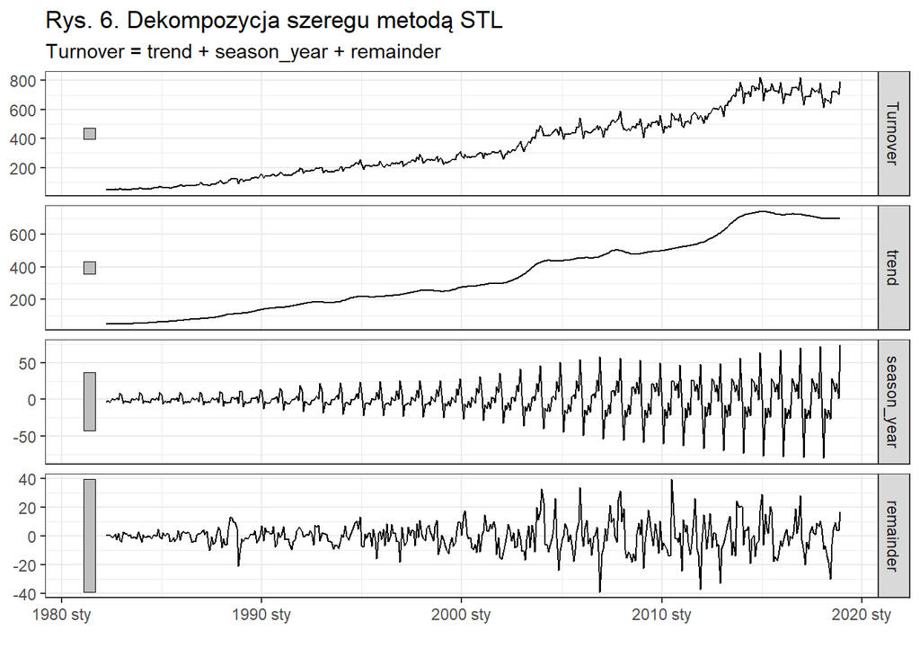

Przeprowadzona dekompozycja metodą STL potwierdza występowanie wyraźnego rosnącego trendu oraz silnych wahań sezonowych w badanym szeregu czasowym. Składowa trendu wskazuje na systematyczny wzrost wartości obrotów na przestrzeni analizowanego okresu, z nieznacznym osłabieniem dynamiki w latach 2008-2010. Składowa sezonowa obrazuje natomiast regularne, coroczne wahania, których amplituda rośnie wraz z poziomem trendu. Podobną zależność można zauważyć w przypadku składnika losowego, którego wahania również zwiększają się w czasie. Zjawisko to świadczy o braku stałej wariancji i sugeruje multiplikatywny charakter szeregu czasowego. Dodatkowo obecność trendu oraz zmiennej wariancji wskazuje, że analizowany szereg nie jest stacjonarny.

W związku z tym zasadne jest zastosowanie przekształcenia, które pozwoli ustabilizować wariancję. Optymalnym rozwiązaniem będzie w tym przypadku transformacja Boxa-Coxa. Do wyznaczenia jej parametru $\small \lambda$ posłużono się metodą Guerrero, która automatycznie dobiera taką wartość $\small \lambda$, by w jak największym stopniu zminimalizować wariancję w całym badanym okresie.

```
## # A tibble: 1 × 3
##   State      Industry                                      lambda_guerrero
##   <chr>      <chr>                                                   <dbl>
## 1 Queensland Cafes, restaurants and takeaway food services           0.142
```

Wyliczona za pomocą metody Guerrero optymalna wartość parametru $\small \lambda$ dla analizowanego szeregu wynosi około 0.142. Wartość ta jest bliska zeru, co wskazuje, że najbardziej odpowiednia jest transformacja zbliżona do logarytmicznej.

## 3. Przygotowanie danych

### 3.1. Podział na zbiór uczący i testowy

Analizowany szereg czasowy podzielono na zbiór uczący oraz testowy. Do estymacji modeli wykorzystano obserwacje sprzed 2011 roku, natomiast dane z kolejnych lat przeznaczono do oceny trafności prognoz.

### 3.2. Badanie stacjonarności szeregu

Wstępną ocenę stacjonarności przeprowadzono na podstawie wizualnej analizy wykresu szeregu czasowego.

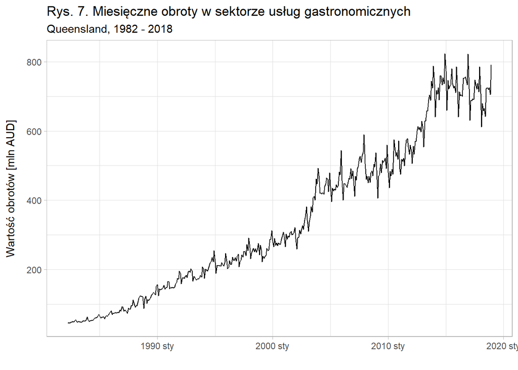

Widoczny na wizualizacji silny trend rosnący oraz zwiększająca się amplituda wahań w kolejnych latach sugerują, że analizowany szereg nie jest stacjonarny. Następnie przeanalizowano funkcję autokorelacji, opisującą zależności pomiędzy bieżącymi i opóźnionymi wartościami szeregu.

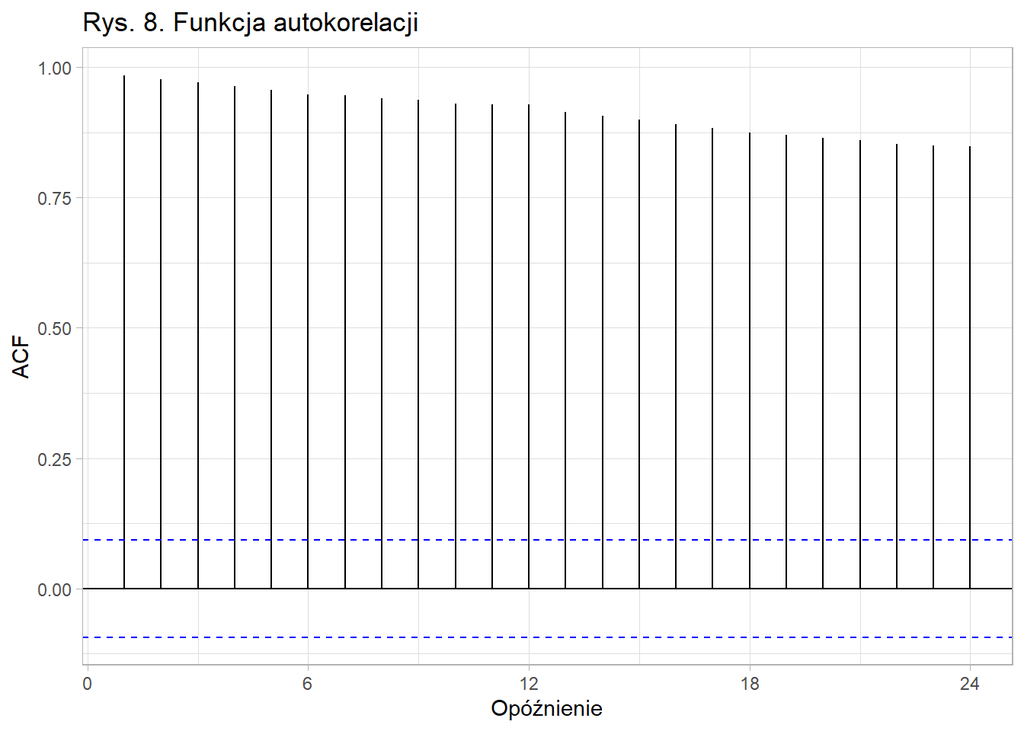

Na wykresie obserwuje się wysokie wartości autokorelacji utrzymujące się dla wielu kolejnych opóźnień oraz ich powolny spadek. Wskazuje to na silną zaleźność pomiędzy obserwacjami, charakterystyczną dla szeregów niestacjonarnych. W celu formalnego potwierdzenia tych obserwacji przeprowadzono test ADF.

```
##
##  Augmented Dickey-Fuller Test
##
## data:  myseries$Turnover
## Dickey-Fuller = -2.8494, Lag order = 7, p-value = 0.2186
## alternative hypothesis: stationary
```

Uzyskana wartość p-value wynosi 0.2186, a więc przekracza przyjęty poziom istotności równy 0.05. Oznacza to, że nie ma podstaw do odrzucenia hipotezy zerowej o występowaniu pierwiastka jednostkowego. Wynik testu potwierdza zatem, że analizowany szereg jest niestacjonarny. W związku z tym, w kolejnym kroku wyznaczono sugerowaną liczbę różnicowań potrzebnych do osiągnięcia stacjonarności szeregu czasowego.

```
## # A tibble: 1 × 3
##   State      Industry                                      ndiffs
##   <chr>      <chr>                                          <int>
## 1 Queensland Cafes, restaurants and takeaway food services      1
```

Otrzymany wynik wskazuje na konieczność zastosowania jednego różnicowania.

## 4. Proste modele prognostyczne

### 4.1. Metoda sezonowa naiwna

Wstępnym etapem modelowania było wyznaczenie prognozy naiwnej tzw. benchmarku, względem którego porównywano bardziej zaawansowane algorytmy. Biorąc pod uwagę zdiagnozowaną wcześniej silną sezonowość analizowanego szeregu, jako model bazowy wybrano model naiwny z przesunięciem sezonowym.

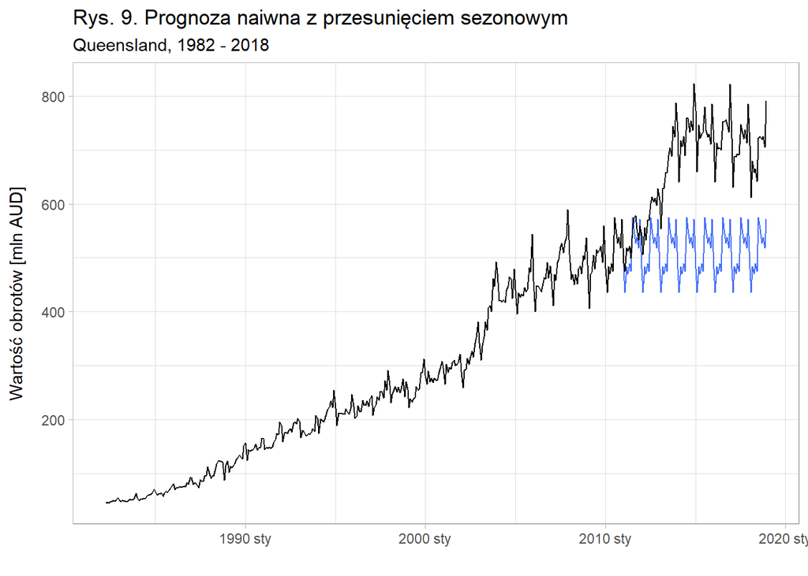

Z Rys. 9 wynika, że prognoza sezonowa naiwna, oznaczona na wykresie kolorem niebieskim, bardzo dobrze odwzorowuje powtarzające się wahania występujące w kolejnych latach, jednakże nie uwzględnia rosnącego trendu obrotów. W konsekwencji prognozy są systematycznie niższe od rzeczywistych wartości ze zbioru testowego, a widoczna rozbieżność stopniowo się powiększa. Z tego względu metoda ta powinna być traktowana jedynie jako punkt odniesienia.

### 4.2. Transformacja Boxa-Coxa i odsezonowienie

W kolejnym kroku sprawdzono, czy odpowiednie przygotowanie danych może przyczynić się do poprawy wyników prognoz. W tym celu ustabilizowano wariancję szeregu czasowego, stosując transformację Boxa-Coxa z parametrem $\small \lambda$ wyznaczonym metodą Guerrero, a następnie wyeliminowano regularne wahania poprzez odsezonowienie metodą STL. Na tej podstawie zbudowano i porównano modele bazujące wyłacznie na wspomnianej transformacji z modelami, które dodatkowo zostały odsezonowane.

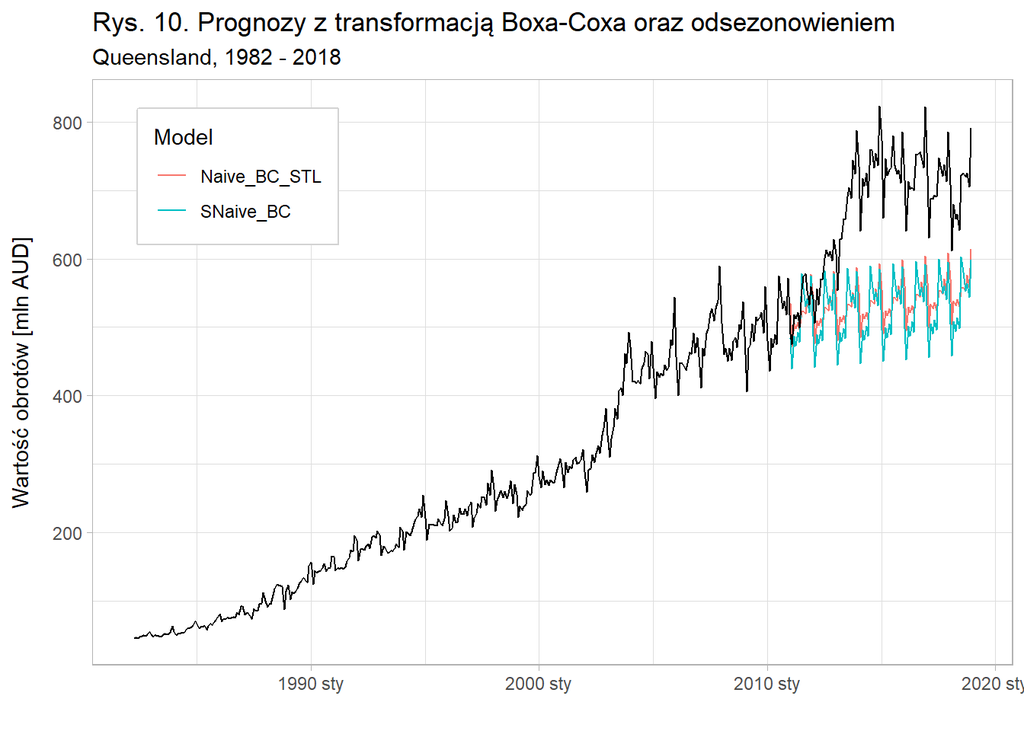

Można zauważyć, że model wykorzystujący transformację Boxa-Coxa wraz z odsezonowieniem (`Naive_BC_STL`) charakteryzuje się nieco bardziej stabilną prognozą. Mimo to, nadal widoczne są istotne różnice względem wartości rzeczywistych.

### 4.3. Porównanie jakości prognoz i analiza reszt

Prognozy uzyskane dla wszystkich rozważanych wariantów umieszczono na wspólnym wykresie, co umożliwiło bezpośrednie porównanie ich skuteczności. Dodatkowo analizę uzupełniono o tabelę, która zawiera miary jakości dopasowania, wyznaczone zarówno na zbiorze uczącym, jak i testowym.

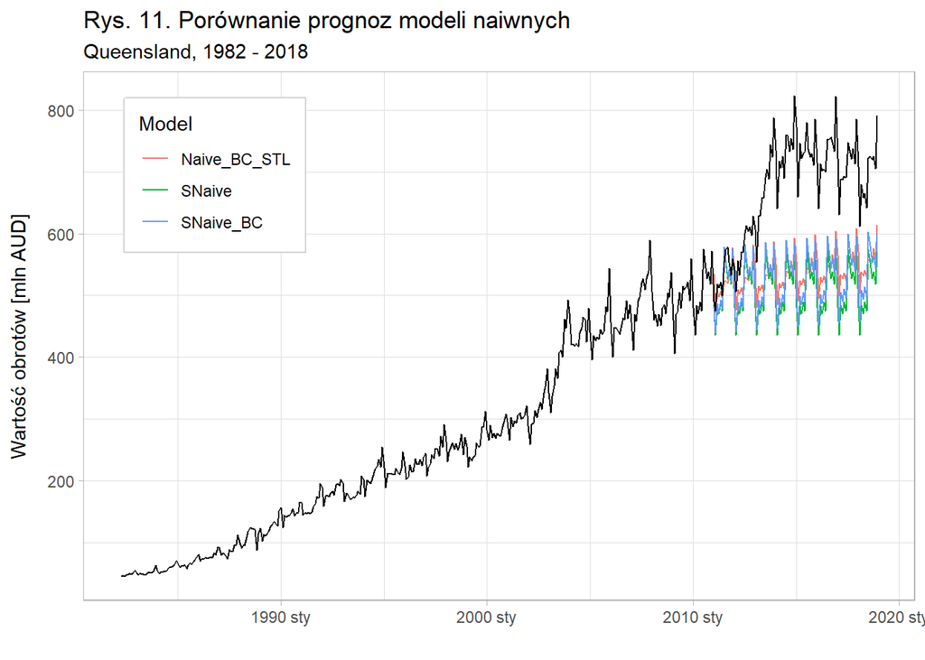

Tab. 1. Zestawienie miar jakości prognoz dla modeli naiwnych

| Model | Typ | RMSE | MAE | MAPE | MASE |
| --- | --- | --- | --- | --- | --- |
| Naive_BC_STL | Training | 11.9809 | 8.2420 | 3.3563 | 0.3732 |
| Naive_BC_STL | Test | 153.9202 | 138.8652 | 19.6688 | — |
| SNaive | Training | 30.7489 | 22.0868 | 9.3236 | 1.0000 |
| SNaive | Test | 179.9779 | 163.8292 | 23.3913 | — |
| SNaive_BC | Training | 30.7489 | 22.0868 | 9.3236 | 1.0000 |
| SNaive_BC | Test | 165.2526 | 149.9832 | 21.4110 | — |

Z analizy Rys. 11 wynika, że żaden z modeli nie jest w stanie w pełni odwzorować dynamiki zjawiska, ponieważ wyznaczone prognozy we wszystkich przypadkach pozostają niedoszacowane względem wartości rzeczywistych. Niemniej jednak model uwzględniający transformację Boxa-Coxa oraz odsezonowanie charakteryzuje się najlepszym dopasowaniem spośród analizowanych wariantów. Potwierdzają to wartości miar jakości przedstawione w Tab. 1, dla których model ten osiągnął najniższe wartości RMSE, MAE oraz MAPE dla zbioru testowego. Dodatkowo uzyskana wartość wskaźnika MASE równa 0.3732 wskazuje na lepsze dopasowanie względem podejścia sezonowego naiwnego. Należy jednak zwrócić uwagę na wyraźną różnicę pomiędzy wartościami błędów wyznaczonymi na zbiorach uczącym oraz testowym, co świadczy o występowaniu zjawiska przeuczenia.

Ostatni etap prac stanowiła analiza reszt dla najskuteczniejszego z badanych modeli, czyli podejścia opartego na transformacji Boxa-Coxa oraz odsezonowaniu.

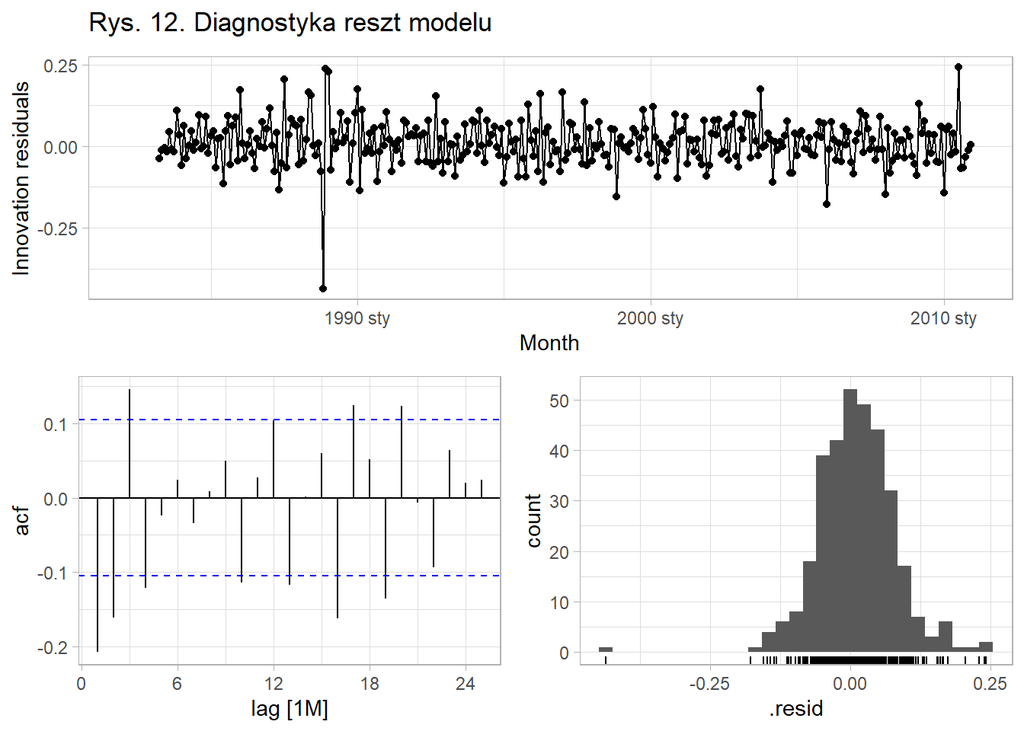

```
## # A tibble: 1 × 3
##   .model       lb_stat lb_pvalue
##   <chr>          <dbl>     <dbl>
## 1 Naive_BC_STL    13.2  0.000276
```

Analiza przedstawionych wizualizacji wskazuje, że choć reszty w większości oscylują wokół zera, w okolicach 1990 roku widoczne jest wyraźne ujemne odchylenie. Przekłada się to na asymetryczny kształt histogramu z wydłużonym lewym ogonem. Dodatkowo wykres ACF sugeruje, że reszty nie mają charakteru białego szumu, co oznacza, że model nie wychwycił wszystkich zależności ukrytych w danych. Ostatecznie wnioski te potwierdza wynik testu Ljunga–Boxa, który wskazuje na istotną autokorelację reszt.

## 5. Modele wygładzania wykładniczego

### 5.1. Multiplikatywna metoda Holta-Wintersa

W kolejnej części projektu testowano wykorzystanie modeli ETS do prognozowania wartości obrotów w branży gastronomicznej w Queensland. Skupiono się na multiplikatywnej metodzie Holta-Wintersa, w ramach której opracowano dwa modele: pierwszy, który uwzględnia wygaszanie trendu oraz drugi bez wygaszenia tj. z trendem addytywnym. Modele te są odpowiednio postaci: ETS(M,Ad,M) oraz ETS(M,A,M). Uzyskane prognozy umieszczono na wspólnym wykresie razem z krzywą przedstawiającą rzeczywiste dane ze zbioru testowego oraz uzupełniono o tabelę, zawierającą miary trafności prognoz, wyznaczone na zbiorach uczącym i testowym.

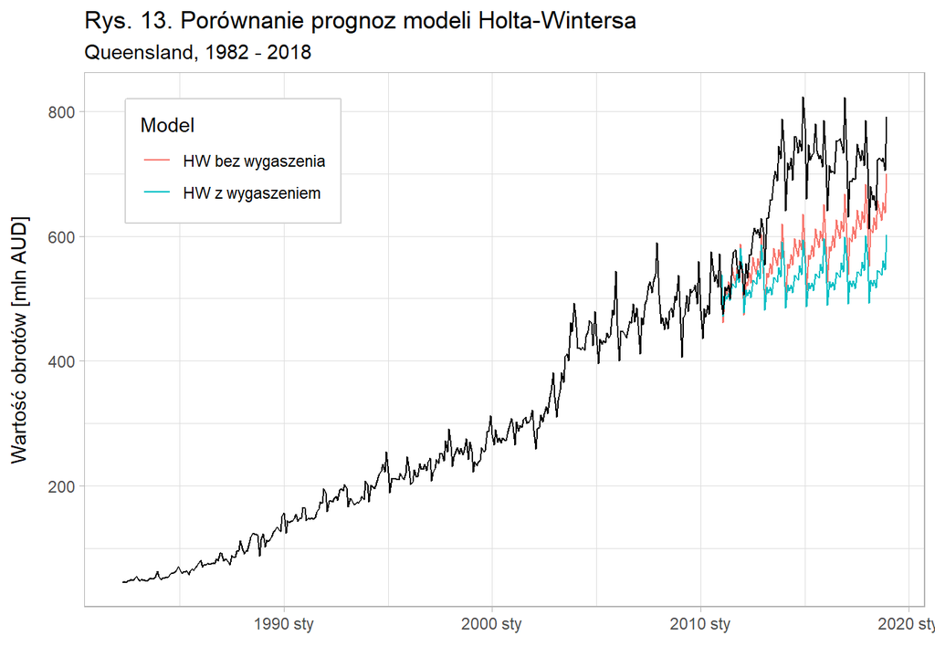

Tab. 2. Zestawienie miar jakości prognoz dla modeli Holta-Wintersa

| Model | Typ | RMSE | MAE | MAPE | MASE |
| --- | --- | --- | --- | --- | --- |
| HW bez wygaszenia | Training | 12.0592 | 7.9858 | 3.2596 | 0.3616 |
| HW bez wygaszenia | Test | 111.4914 | 97.8126 | 13.8427 | — |
| HW z wygaszeniem | Training | 11.6563 | 7.7035 | 3.1428 | 0.3488 |
| HW z wygaszeniem | Test | 157.9635 | 142.4493 | 20.1681 | — |

### 5.2. Analiza reszt modelu

Jako, że za lepszy uznano model Holta-Wintersa bez wygaszania trendu, w kolejnym kroku dokonano analizy jego reszt, sprawdzając, czy zachowują się one jak biały szum.

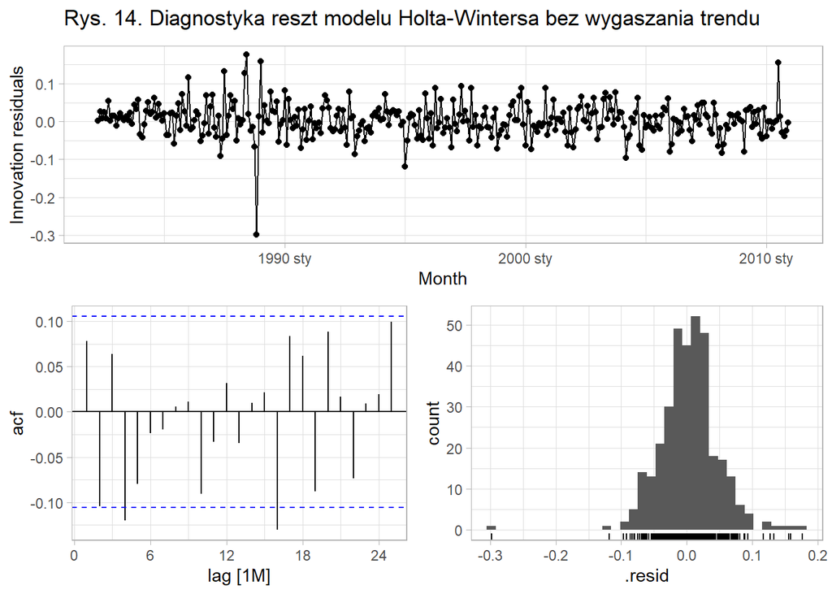

```
## # A tibble: 1 × 3
##   .model            lb_stat lb_pvalue
##   <chr>               <dbl>     <dbl>
## 1 HW bez wygaszenia    4.89    0.0271
```

Na przedstawionych wizualizacjach można zauważyć, że generalnie reszty oscylują wokół zera ze stabilną wariancją, co przypomina biały szum. Widoczna jest jednak wyraźna, ujemna wartość odstająca występująca w okolicach 1989 roku, która zaburza symetrię histogramu. Wykres autokorelacji (ACF) ujawnia ponadto, że opóźnienia dla 4. i 16. miesiąca przekraczają granice istotności statystycznej, co wskazuje na niewyjaśnione kwartalne zależności w danych. Ostatecznie przeprowadzony test Ljunga-Boxa wykazał wartość p równą 0.0271, co oznacza obecność istotnej autokorelacji reszt przy standardowym poziomie istotności 95%, a tym samym podstawy do odrzucenia hipotezy o białym szumie., przy jednoczesnym braku podstaw do jej odrzucenia na bardziej rygorystycznym poziomie 99%. Oznacza to, że model ten, mimo uzyskania znacznie lepszych wyników w porównaniu z analizowanym wcześniej modelem opartym na transformacji Boxa-Coxa i odsezonowaniu, nie wychwycił z szeregu wszystkich dostępnych informacji, co sugeruje potrzebę przetestowania innych, bardziej elastycznych modeli.

### 5.3. Porównanie modelu z prognozą naiwną

W celu dalszej analizy wybranego modelu Holta-Wintersa bez wygaszania trendu, zestawiono otrzymane za jego pomocą wyniki z rezultatami zastosowanej wcześniej prognozy sezonowej naiwnej za pomocą wykresu oraz tabeli z wartościami RMSE.

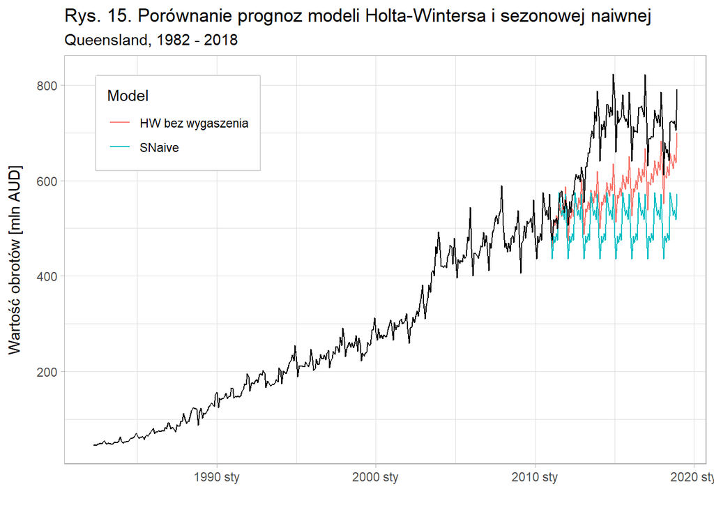

Tab. 3. Zestawienie miar jakości prognoz dla modeli Holta-Wintersa i sezonowego naiwnego

| Model | Typ | RMSE | MAE | MAPE | MASE |
| --- | --- | --- | --- | --- | --- |
| HW bez wygaszenia | Training | 12.0592 | 7.9858 | 3.2596 | 0.3616 |
| HW bez wygaszenia | Test | 111.4914 | 97.8126 | 13.8427 | — |
| SNaive | Training | 30.7489 | 22.0868 | 9.3236 | 1.0000 |
| SNaive | Test | 179.9779 | 163.8292 | 23.3913 | — |

### 5.4. Model ETS dla danych skorygowanych sezonowo i przekształconych

W kolejnym kroku analizy podjęto próbę poprawy wyników prognoz poprzez zastosowanie modelu ETS na danych skorygowanych sezonowo z wykorzystaniem dekompozycji STL oraz dodatkowo przekształconych za pomocą transformacji Boxa-Coxa. Otrzymane rezultaty przedstawiono na wykresie i w tabeli, zestawiając je z wynikami poprzedniej metody (Holta-Wintersa bez wygaszania trendu).

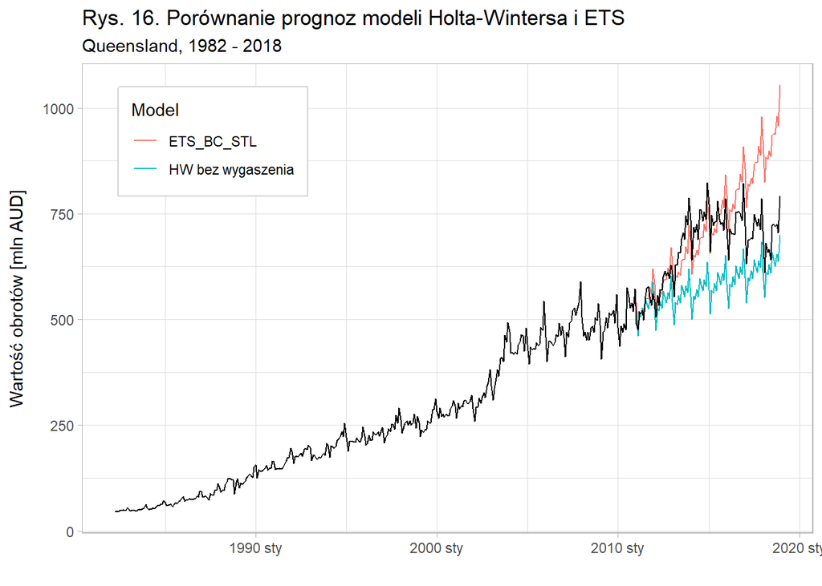

Tab. 4. Zestawienie miar jakości prognoz dla modeli Holta-Wintersa i ETS

| Model | Typ | RMSE | MAE | MAPE | MASE |
| --- | --- | --- | --- | --- | --- |
| ETS_BC_STL | Training | 11.6671 | 7.8383 | 3.1794 | 0.3549 |
| ETS_BC_STL | Test | 104.0022 | 75.4856 | 10.8285 | — |
| HW bez wygaszenia | Training | 12.0592 | 7.9858 | 3.2596 | 0.3616 |
| HW bez wygaszenia | Test | 111.4914 | 97.8126 | 13.8427 | — |

Patrząc na wykres (Rys. 16), widać wyraźną różnicę w zachowaniu obu metod na zbiorze testowym. Model Holta-Wintersa bez wygaszenia trendu przez niemal cały okres prognozy niedoszacowuje wartości obrotów względem danych rzeczywistych. Natomiast model ETS z dekompozycją STL i transformacją Boxa-Coxa o wiele lepiej radzi sobie w pierwszej części okresu prognozy, bardzo dobrze naśladując rzeczywiste wartości. Jednak w drugiej części badanego okresu, gdzie w rzeczywistych danych trend rosnący wygasł, a wręcz zaczął być malejący, model ten zaczyna zbyt mocno piąć się w górę i wyraźnie zawyża wyniki. Mimo tego wartości przedstawione w tabeli (Tab. 4) potwierdzają, że to model oparty na dekompozycji STL jest ogólnie dokładniejszy. Osiągnął on niższy błąd RMSE na zbiorze testowym, wynoszący 104, w porównaniu z wartością 111.49 uzyskaną dla modelu Holta-Wintersa bez wygaszania trendu. Podsumowując, oczyszczenie danych z wykorzystaniem dekompozycji STL oraz zastosowanie transformacji Boxa-Coxa pozwoliło poprawić jakość prognoz i zmniejszyć błąd predykcji w analizowanym okresie, choć przy wydłużaniu horyzontu prognozy model ten ma tendencję do zawyżania wartości.

## 6. Modele ARIMA

### 6.1. Model Auto ARIMA

Kolejnym etapem badania jest zastosowanie automatycznego modelu ARIMA, który pozwala na precyzyjne uchwycenie zależności autoregresyjnych oraz wpływu przeszłych błędów prognozy na bieżące i przyszłe wartości obrotów. Z uwagi na wyraźną niestacjonarność pierwotnego szeregu czasowego, objawiającą się zarówno występowaniem trendu, jak i rosnącą amplitudą wahań sezonowych, kluczowe było odpowiednie przygotowanie danych wejściowych. W tym celu dane poddano uprzednio przekształceniu za pomocą transformacji Boxa-Coxa z automatycznie dobranym parametrem $\small \lambda$, co zapewniło stabilizację ich wariancji.

```
## Series: Turnover
## Model: ARIMA(0,1,4)(0,1,1)[12]
## Transformation: box_cox(Turnover, lambda)
##
## Coefficients:
##           ma1      ma2     ma3      ma4     sma1
##       -0.2718  -0.1463  0.1257  -0.1589  -0.8609
## s.e.   0.0548   0.0558  0.0571   0.0566   0.0377
##
## sigma^2 estimated as 0.004809:  log likelihood=409.17
## AIC=-806.35   AICc=-806.09   BIC=-783.52
```

Na podstawie raportu widać, że automatyczny algorytm dopasował model sezonowy oznaczony jako ARIMA(0,1,4)(0,1,1)[12], który opiera się na postaci modelu SARIMA: ARIMA(p, d, q)(P, D, Q)[m]. W zapisie tym pierwszy nawias odpowiada za część opisującą krótkookresowe relacje między kolejnymi miesiącami, a drugi reprezentuje komponent sezonowy, odpowiedzialny za wychwytywanie długookresowych zależności. Indeks dolny 12 oznacza, że mamy do czynienia z danymi miesięcznymi, których pełny cykl sezonowy trwa rok. Parametry różnicowania (d=1 oraz D=1) oznaczają, że początkowy szereg był niestacjonarny. Aby to naprawić, model musiał dwukrotnie obliczyć różnice między wartościami: z miesiąca na miesiąc (d=1), żeby usunąć długoterminowy trend oraz rok do roku (D=1), co oczyściło dane z sezonowości. Wartości p=0 oraz P=0 oznaczają brak autoregresji, czyli informują, że model nie łączy obecnych obrotów bezpośrednio z wynikami z przeszłości. Wartość q=4 oznacza, że algorytm koryguje bieżący wynik na podstawie błędów prognoz z czterech ostatnich miesięcy. Z kolei wartość Q=1 oznacza, że na wynik wpływa błąd prognozy sprzed roku. Niskie błędy standardowe potwierdzają, że wyliczenia modelu są stabilne i wiarygodne. Dobrą jakość tak skonstruowanego modelu potwierdzają także silnie ujemne wartości kryteriów informacyjnych (AIC, AICc oraz BIC). Dowodzą one, że model jest dobrze dopasowany do historii, a jednocześnie nie jest zbyt skomplikowany, co chroni go przed utratą skuteczności przy przewidywaniu przyszłości.

### 6.2. Sprawdzenie stacjonarności

```
##
##  Augmented Dickey-Fuller Test
##
## data:  turnover_diff$Turnover_stationary[-c(1:13)]
## Dickey-Fuller = -7.7438, Lag order = 6, p-value = 0.01
## alternative hypothesis: stationary
```

Sprawdzenie stacjonarności danych bazowych, na których ostatecznie oparto szacowanie współczynników, przedstawia test ADF. Uzyskana wartość p-value równa 0.01 pozwala jednoznacznie odrzucić hipotezę zerową o niestacjonarności. Stanowi to formalny dowód na to, że model ARIMA bazuje na w pełni stacjonarnym szeregu, co gwarantuje poprawność matematyczną prognozy.

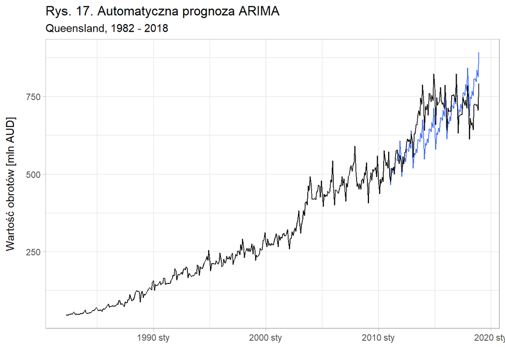

Tab. 5. Zestawienie miar jakości prognoz dla modelu auto ARIMA

| Model | Typ | RMSE | MAE | MAPE | MASE |
| --- | --- | --- | --- | --- | --- |
| ARIMA_BC | Training | 11.7070 | 7.7242 | 3.0422 | 0.3497 |
| ARIMA_BC | Test | 66.7615 | 54.8165 | 7.8545 | — |

Wizualizacja uzyskanych wyników przedstawiona na Rys. 17 pokazuje, że linia prognozy bardzo dobrze odwzorowuje rzeczywiste dane w pierwszej części zbioru testowego. Podobnie jak w przypadku modelu z dekompozycją STL, w samym końcu okresu, bliżej 2020 roku, widoczna jest tendencja do dawania zbyt wysokich wyników, co wynika z nagłego wygaszenia rzeczywistego trendu, którego model uczący się na danych historycznych nie mógł przewidzieć. Mimo tego końcowego odchylenia model okazał się wyjątkowo dokładny. Zgodnie z danymi zawartymi w Tab. 5, błąd RMSE na zbiorze testowym wynosi zaledwie 66.8, co jest zdecydowanie najlepszym wynikiem spośród wszystkich dotychczas rozważanych modeli.

## 7. Porównanie metod prognostycznych

Ostatnim elementem analizy jest przetestowanie modeli należących do innych rodzin oraz zastosowanie ich na do danych przygotowanych w różny sposób. Dla każdej rodziny zbudowano trzy modele: na danych bez przekształceń, na danych poddanych transformacji Boxa-Coxa (`_BC`) oraz na danych zarówno przekształconych, jak i odsezonowionych z wykorzystaniem dekompozycji STL (`_BC_STL`). Uzyskane wyniki przedstawiono w poniższych tabelach, oddzielnie dla każdej rodziny modeli.

Tab. 6. Zestawienie miar jakości prognoz dla modeli ETS

| Model | Typ | RMSE | MAE | MAPE | MASE |
| --- | --- | --- | --- | --- | --- |
| ETS | Training | 11.6563 | 7.7035 | 3.1428 | 0.3488 |
| ETS | Test | 157.9635 | 142.4493 | 20.1681 | — |
| ETS_BC | Training | 11.6214 | 7.8097 | 3.2252 | 0.3536 |
| ETS_BC | Test | 95.9616 | 70.8279 | 10.1754 | — |
| ETS_BC_STL | Training | 11.6671 | 7.8383 | 3.1794 | 0.3549 |
| ETS_BC_STL | Test | 104.0022 | 75.4856 | 10.8285 | — |

Wśród modeli ETS najlepszy pod względem wartości RMSE, zarówno na zbiorze uczącym, jak i testowym okazał się model bazujący wyłącznie na transformacji Boxa-Coxa. Zastosowanie dodatkowo dekompozycji STL przyczyniło się do pogorszenia wyników.

Tab. 7. Zestawienie miar jakości prognoz dla modeli ARIMA

| Model | Typ | RMSE | MAE | MAPE | MASE |
| --- | --- | --- | --- | --- | --- |
| ARIMA | Training | 12.0813 | 8.2464 | 3.4464 | 0.3734 |
| ARIMA | Test | 103.8058 | 90.2880 | 12.8033 | — |
| ARIMA_BC | Training | 11.7070 | 7.7242 | 3.0422 | 0.3497 |
| ARIMA_BC | Test | 66.7615 | 54.8165 | 7.8545 | — |
| ARIMA_BC_STL | Training | 11.6333 | 7.8372 | 3.1257 | 0.3548 |
| ARIMA_BC_STL | Test | 106.8687 | 76.8514 | 11.0463 | — |

Tab. 8. Zestawienie miar jakości prognoz dla modeli Theta

| Model | Typ | RMSE | MAE | MAPE | MASE |
| --- | --- | --- | --- | --- | --- |
| Theta | Training | 11.4846 | 7.7188 | 3.1823 | 0.3495 |
| Theta | Test | 139.6347 | 125.9113 | 17.8702 | — |
| Theta_BC | Training | 11.5985 | 7.8795 | 3.2322 | 0.3568 |
| Theta_BC | Test | 85.6165 | 70.3331 | 10.0970 | — |
| Theta_BC_STL | Training | 11.9390 | 8.0033 | 3.2237 | 0.3624 |
| Theta_BC_STL | Test | 76.5895 | 61.3477 | 8.7345 | — |

Dla metody Theta najlepsze wyniki na zbiorze testowym uzyskał model oparty na danych odsezonowionych za pomocą dekompozycji STL oraz przekształconych transformacją Boxa-Coxa.

Tab. 9. Zestawienie miar jakości prognoz dla modeli regresji liniowej

| Model | Typ | RMSE | MAE | MAPE | MASE |
| --- | --- | --- | --- | --- | --- |
| LM | Training | 31.2359 | 24.8181 | 14.5920 | 1.1237 |
| LM | Test | 107.0641 | 91.6960 | 12.8993 | — |
| LM_BC | Training | 37.9795 | 26.7604 | 12.0983 | 1.2116 |
| LM_BC | Test | 257.2860 | 229.4003 | 33.9417 | — |
| LM_BC_STL | Training | 38.5761 | 27.2538 | 11.6532 | 1.2339 |
| LM_BC_STL | Test | 257.0579 | 229.0117 | 33.8662 | — |

Modele regresji liniowej osiągnęły wysokie wartości błędu RMSE na zbiorze uczącym, a także wyjątkowo wysokie na zbiorze testowym, szczególnie w przypadku wariantów działających na danych przekształconych, gdzie błąd wyniósł aż 257. Wobec tego jako najlepszy z tej rodziny wybrano model zbudowany na danych surowych, czyli bez transformacji Boxa-Coxa oraz bez dekompozycji STL.

Tab. 10. Zestawienie miar jakości prognoz dla sieci neuronowej

| Model | Typ | RMSE | MAE | MAPE | MASE |
| --- | --- | --- | --- | --- | --- |
| NNETAR | Training | 17.7634 | 12.1109 | 4.6912 | 0.5483 |
| NNETAR | Test | 181.6327 | 162.5933 | 22.9182 | — |
| NNETAR_BC | Training | 17.7374 | 12.1174 | 4.6988 | 0.5486 |
| NNETAR_BC | Test | 183.0929 | 164.0093 | 23.1228 | — |
| NNETAR_BC_STL | Training | 11.3453 | 7.7277 | 3.1588 | 0.3499 |
| NNETAR_BC_STL | Test | 196.2244 | 179.7095 | 25.5709 | — |

W modelach sieci neuronowych widoczne są ogromne różnice pomiędzy wynikami na zbiorze uczącym i testowym. Na danych historycznych błędy są bardzo małe (RMSE rzędu 11–17), jednak przy prognozowaniu przyszłych wartości gwałtownie rosną do poziomu 182–196. Świadczy to o silnym przeuczeniu modeli, które zbyt mocno dopasowały się do danych treningowych i utraciły zdolność do skutecznego prognozowania nowych obserwacji. Wybór najlepszego wariantu z tej rodziny nie jest jednoznaczny. Na zbiorze uczącym najlepiej wypadł model z transformacją Boxa-Coxa i dekompozycją STL, odnotowując najniższe wartości wszystkich miar błędów. Jednak na zbiorze testowym poradził on sobie najgorzej, osiągając wartość RMSE równą 196.22. Pozostałe warianty, oparte na danych surowych oraz po samej transformacji Boxa-Coxa, wypadły porównywalnie, przy czym model zbudowany na danych bez żadnych przekształceń minimalnie okazał się najlepszy na zbiorze testowym.

Zwieńczeniem przeprowadzonej analizy jest zbiorcze zestawienie i porównanie najlepszych modeli z każdej rodziny, co pozwala na ocenę, która z metod najlepiej radzi sobie z odzwierciedleniem specyfiki badanego szeregu czasowego. Wizualizacja wszystkich uzyskanych prognoz na tle rzeczywistych danych została przedstawiona na wykresie (Rys. 18), a wartości ich błędów w tabeli (Tab. 11). Uwzględniono także model na danych odsezonowionych za pomocą dekompozycji STL, z transformacją Boxa-Coxa z metody naiwnej, który uznano za najlepszy z tej rodziny we wcześniejszym etapie analizy (Tab. 1).

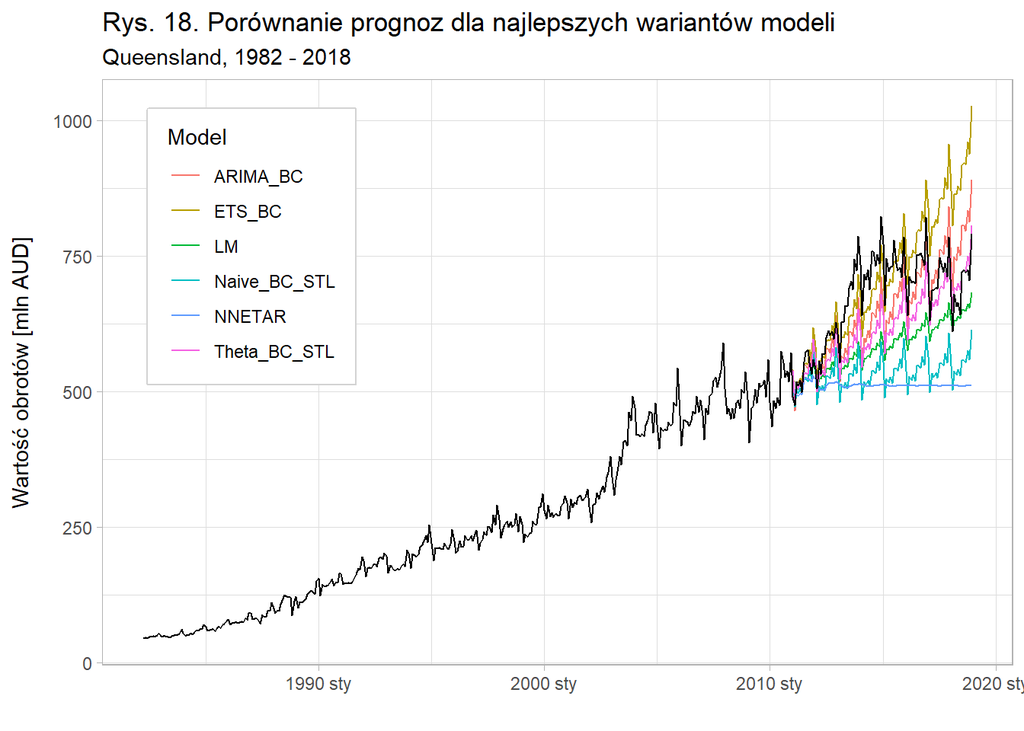

Tab. 11. Zestawienie miar jakości prognoz dla najlepszych wariantów modeli

| Model | Typ | RMSE | MAE | MAPE | MASE |
| --- | --- | --- | --- | --- | --- |
| ARIMA_BC | Training | 11.7070 | 7.7242 | 3.0422 | 0.3497 |
| ARIMA_BC | Test | 66.7615 | 54.8165 | 7.8545 | — |
| ETS_BC | Training | 11.6214 | 7.8097 | 3.2252 | 0.3536 |
| ETS_BC | Test | 95.9616 | 70.8279 | 10.1754 | — |
| LM | Training | 31.2359 | 24.8181 | 14.5920 | 1.1237 |
| LM | Test | 107.0641 | 91.6960 | 12.8993 | — |
| NNETAR | Training | 17.7634 | 12.1109 | 4.6912 | 0.5483 |
| NNETAR | Test | 181.6327 | 162.5933 | 22.9182 | — |
| Naive_BC_STL | Training | 11.9809 | 8.2420 | 3.3563 | 0.3732 |
| Naive_BC_STL | Test | 153.9202 | 138.8652 | 19.6688 | — |
| Theta_BC_STL | Training | 11.9390 | 8.0033 | 3.2237 | 0.3624 |
| Theta_BC_STL | Test | 76.5895 | 61.3477 | 8.7345 | — |